# R for Register Data Users

```r
# Tabulate variable (data.table)
data[,.(N=.N),by=.(SEX)] # This is an example of using the j and by syntax
```

```
##      SEX     N
##    <int> <int>
## 1:     2 46431
## 2:     1 43545
```

You can do this with more than one variable

```r
table(data$SEX,data$EDUC)
```

```
##
##        0  102  104  105  106  107  108  109  110  111  113  114  115  116  201
##   1 3371 1724  741  767  860  837  889 1431  883 1287 1416 1420 1473  758 7848
##   2 3235 1533  763  740  790  807  852 1356  816 1249 1523 1471 1567  783 8474
##
##      202  301  302  303  400  510  521  522  997  998  999
##   1  977 5646 1761  879 5018 1881  476  492  343   27  340
##   2  926 6757 2272 1377 5662 2206  292  298  335   19  328
```

Let’s say we find these ALL CAPS variable names annoying. We can rename as follows

```r
# Rename syntax example
old_names <- names(data)
new_names <- str_to_lower(old_names)

setnames(data,old_names,new_names)
```

Note that we could have just changed some names. In a typical workflow, the next step might be to recode the variables based on info from the NHIS documentation.

```r
# Code sex to factor (j syntax to create or modify variable)
data[,sex:=fifelse(sex==1,'male','female')] # This works like ifelse but it's more efficient

# Code marital status and simplify
data[
  ,
  mar_stat:=fcase(
    marstcur==0,'not asked',
    between(marstcur,1,3),'married', # Alternative syntax marstcur %in% 1:3
    marstcur==4,'separated',
    marstcur==5,'divorced',
    marstcur==6,'widowed',
    marstcur==7,'cohabiting',
    marstcur==8,'never married',
    marstcur==9,NA_character_
  )
]

# Remove original variable (efficiently because no copying occurrs)
data[,marstcur:=NULL]

# Recode race
data[
  ,
  race:=fcase(
    racenew==100,'white',
    racenew==200,'black',
    racenew==300,'AIAN',
    racenew==400,'asian',
    racenew==530,NA_character_,
    racenew==541,'multirace'
  )
]

# Remove original variable
data[,racenew:=NULL]

# Recode hispanic origin and simplify (alternative syntax)
data[,hispanic:='hispanic']
data[hispeth==10,hispanic:='non hispanic']

# Remove original variable
data[,hispeth:=NULL]

# Recode education and simplify
data[
  ,
  edu:=fcase(
    educ==0,'not asked',
    between(educ,100,116),'less than high school',
    between(educ,200,202),'high school',
    between(educ,300,303),'some college',
    educ==400,'bachelor',
    educ>400 & educ<900,'graduate',
    educ>=900,NA_character_
  )
]

# Remove original variable
data[,educ:=NULL]

# Recode BMI and simplify
data[
  ,
  bmi:=fcase(
    bmicat==1,'<18.5',
    bmicat==2,'18.5-25',
    bmicat==3,'25-30',
    bmicat==4,'>30',
    bmicat==9,NA_character_
  )
]

# Remove original variable
data[,bmicat:=NULL]

# Set correct missing values for continuous BMI
data[,bmi_c := bmicalc]
data[is.na(bmi),bmi_c:=NA_real_]

# Remove original variable (efficiently)
data[,bmicalc:=NULL]

# Recode smoking status
data[
  ,
  smoke:=fcase(
    smokestatus2==11,'every day smoker',
    smokestatus2==12,'some day smoker',
    smokestatus2==20,'former smoker',
    smokestatus2==30,'never smoker',
    smokestatus2==40,NA_character_,
    smokestatus2==90,NA_character_
  )
]

# Remove original variable (efficiently)
data[,smokestatus2:=NULL]
```

Let’s take a look at our cleaned dataset.

```r
str(data)
```

```
## Classes 'data.table' and 'data.frame':   89976 obs. of  12 variables:
##  $ nhishid    : int  2010000001 2010000001 2010000001 2010000002 2010000002 2010000002 2010000006 2010000006 2010000006 2010000006 ...
##  $ perweight  : int  3248 3981 3181 1454 1370 1607 4661 4396 4228 4285 ...
##  $ age        : int  43 42 11 24 27 25 42 42 17 14 ...
##  $ sex        : chr  "female" "male" "female" "female" ...
##  $ diabeticage: int  96 96 96 96 96 96 96 96 96 96 ...
##  $ mar_stat   : chr  "married" "married" "not asked" "never married" ...
##  $ race       : chr  "white" "white" "white" "white" ...
##  $ hispanic   : chr  "hispanic" "hispanic" "hispanic" "hispanic" ...
##  $ edu        : chr  "graduate" "graduate" "less than high school" "high school" ...
##  $ bmi        : chr  "<18.5" NA NA NA ...
##  $ bmi_c      : num  18.2 NA NA NA NA 23 30.8 NA NA NA ...
##  $ smoke      : chr  "former smoker" NA NA NA ...
##  - attr(*, ".internal.selfref")=<externalptr>
##  - attr(*, "index")= int(0)
```

We can see that all our categorical variables are stored as characters. This is ok but characters don’t have a clear notion of ordering. When we need to define a specific order we can use a factor. We can use this to illustrate one very useful `data.table` trick

```r
# Select columns which we want to modify
vars_to_fct <- c('sex','mar_stat','race','hispanic','edu','bmi','smoke')
# Apply the as.factor function to all columns at the same time
data[,(vars_to_fct):=lapply(.SD,as.factor),.SDcols = vars_to_fct]
```

Check

```r
str(data)
```

```
## Classes 'data.table' and 'data.frame':   89976 obs. of  12 variables:
##  $ nhishid    : int  2010000001 2010000001 2010000001 2010000002 2010000002 2010000002 2010000006 2010000006 2010000006 2010000006 ...
##  $ perweight  : int  3248 3981 3181 1454 1370 1607 4661 4396 4228 4285 ...
##  $ age        : int  43 42 11 24 27 25 42 42 17 14 ...
##  $ sex        : Factor w/ 2 levels "female","male": 1 2 1 1 1 2 2 1 1 2 ...
##  $ diabeticage: int  96 96 96 96 96 96 96 96 96 96 ...
##  $ mar_stat   : Factor w/ 7 levels "cohabiting","divorced",..: 3 3 5 4 4 4 3 3 4 4 ...
##  $ race       : Factor w/ 5 levels "AIAN","asian",..: 5 5 5 5 5 5 5 5 5 5 ...
##  $ hispanic   : Factor w/ 2 levels "hispanic","non hispanic": 1 1 1 1 1 1 2 2 2 2 ...
##  $ edu        : Factor w/ 6 levels "bachelor","graduate",..: 2 2 4 3 3 3 3 3 4 4 ...
##  $ bmi        : Factor w/ 4 levels "<18.5",">30",..: 1 NA NA NA NA 3 2 NA NA NA ...
##  $ bmi_c      : num  18.2 NA NA NA NA 23 30.8 NA NA NA ...
##  $ smoke      : Factor w/ 4 levels "every day smoker",..: 2 NA NA NA NA 3 1 NA NA NA ...
##  - attr(*, ".internal.selfref")=<externalptr>
##  - attr(*, "index")= int(0)
```

We can now order factor variables

```r
data[,edu:=fct_relevel(edu,'less than high school','high school','some college','bachelor','graduate')]
# fct_relevel comes from the forcats library
# We left one level out because I don't like typing but it works because it will automatically be last
```

#### Small Digression

What is this `lapply` thingy a few code blocks above? `lapply` is part of the `apply` family of functions that are sort of compact loops for simple operations. Some examples.

```r
# Define a vector
a <- c('I','you','we','they')

# Add "go" to the end of each string
sapply(a,function(x) paste0(x,' go')) # Vector as output, example of anonymous function
```

```
##         I       you        we      they
##    "I go"  "you go"   "we go" "they go"
```

```r
# If we needed a list, we would do
lapply(a,function(x) paste0(x,' go'))
```

```
## [[1]]
## [1] "I go"
##
## [[2]]
## [1] "you go"
##
## [[3]]
## [1] "we go"
##
## [[4]]
## [1] "they go"
```

```r
# Sum vector elements by group
b <- seq(1:6)
g <- rep(1:3,each=2)
tapply(b,g,sum) # Can be quite useful when working with vectors and matrices!
```

```
##  1  2  3
##  3  7 11
```

```r
# If we felt posh, we could have written
sapply(unique(g),function(x) sum(b[g==x]))
```

```
## [1]  3  7 11
```

```r
# apply is the most general version but I don't find it particularly intuitive

# Define a matrix
my_mat <- matrix(
  c(c(1,2,3),
    c(4,5,6),
    c(7,8,9)),
  byrow = T,
  nrow=3,
  ncol=3
)

# Subtract row mean to each row
t(apply(my_mat,M=1,function(x) x - mean(x))) # M=1 for row-wise operations and M=2 for column-wise
```

```
##      [,1] [,2] [,3]
## [1,]   -1    0    1
## [2,]   -1    0    1
## [3,]   -1    0    1
```

```r
# A more efficient way would be
sweep(my_mat,M=1,STATS=matrixStats::rowMeans2(my_mat),FUN="-")
```

```
##      [,1] [,2] [,3]
## [1,]   -1    0    1
## [2,]   -1    0    1
## [3,]   -1    0    1
```

```r
# matrixStats::rowMeans2(my_mat) is the same as apply(my_mat,M=1,mean) but more efficient
# Sweep is great but the syntax is not intuitive and I always forget what goes where
```

Combining `sapply`, `tapply`, aggregation functions for matrices from `matrixStats`, and `sweep` can get you very far and give you extremely efficient code.

#### Back to Work

We can be proud of our work. Suppose we want to take a look at prevalence of smoking by age, sex, and educational attainment. It probably makes sense to 1) group ages, 2) restrict the sample to certain ages.

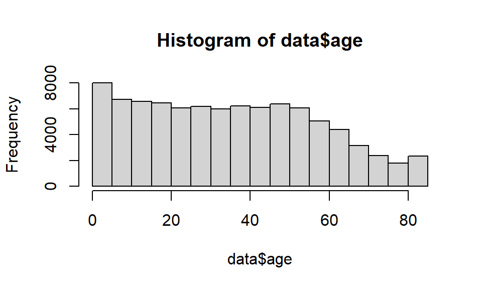

```r
# take a quick look at the age distribution
hist(data$age) # Not pretty but quick (fancy stuff later on)
```

Say we want to create 5-year age groups and a top category for 85+ (the variable is top-coded anyway)

```r
data[,age_group:=cut(age,seq(0,90,5),right=F)] # Not the most straightforward syntax
data[age_group=='[85,90)',age_group:='85+']
```

```r
# The base r way
sweep(
  table(data$age_group,data$smoke,useNA = 'always'),
  M=1,
  table(data$age_group,useNA = 'always'),
  FUN = '/'
  )
```

```
##
##           every day smoker former smoker never smoker some day smoker
##   [0,5)        0.000000000   0.000000000  0.000000000     0.000000000
##   [5,10)       0.000000000   0.000000000  0.000000000     0.000000000
##   [10,15)      0.000000000   0.000000000  0.000000000     0.000000000
##   [15,20)      0.011592894   0.002107799  0.080548028     0.005570611
##   [20,25)      0.050207814   0.027930175  0.254197839     0.021778886
##   [25,30)      0.069866144   0.043258244  0.262650996     0.025954946
##   [30,35)      0.063854425   0.059553350  0.266501241     0.021836228
##   [35,40)      0.061922061   0.055812417  0.261393659     0.019484808
##   [40,45)      0.057593308   0.058236808  0.245495495     0.018178893
##   [45,50)      0.069632191   0.069475008  0.224457718     0.018390443
##   [50,55)      0.080548830   0.091525424  0.195480226     0.017594835
##   [55,60)      0.072066933   0.107815174  0.216200799     0.016923369
##   [60,65)      0.066323245   0.140802747  0.219575016     0.015453960
##   [65,70)      0.059485055   0.176383545  0.230541580     0.009470257
##   [70,75)      0.050695012   0.190515127  0.255110384     0.010629599
##   [75,80)      0.030690537   0.217902813  0.265984655     0.007672634
##   [80,85)      0.022598870   0.201271186  0.336158192     0.007062147
##   [85,90)
##   85+          0.006430868   0.180868167  0.395498392     0.004823151
##   <NA>
##
##                  <NA>
##   [0,5)   1.000000000
##   [5,10)  1.000000000
##   [10,15) 1.000000000
##   [15,20) 0.900180668
##   [20,25) 0.645885287
##   [25,30) 0.598269670
##   [30,35) 0.588254756
##   [35,40) 0.601387054
##   [40,45) 0.620495495
##   [45,50) 0.618044640
##   [50,55) 0.614850686
##   [55,60) 0.586993725
##   [60,65) 0.557845031
##   [65,70) 0.524119562
##   [70,75) 0.493049877
##   [75,80) 0.477749361
##   [80,85) 0.432909605
##   [85,90)
##   85+     0.412379421
##   <NA>
```

```r
# Another good use case for sweep!
```

```r
# The data.table way.
freq_table <- data[,.(N=.N),by=.(age_group,smoke)] # example of grouping and aggregation
freq_table <- freq_table[,freq:=N/(sum(N)),by=.(age_group)] # example of grouping without aggregation

# Taking advantage to illustrate the syntax for a long to wide pivot
freq_table_wide <- dcast(
  freq_table,
  age_group ~ smoke,
  value.var = 'freq',
  fill = 0
)
# I forget the syntax every time even though I use this daily

freq_table_wide
```

```
## Key: <age_group>
##     age_group        NA every day smoker former smoker never smoker
##        <fctr>     <num>            <num>         <num>        <num>
##  1:     [0,5) 1.0000000      0.000000000   0.000000000   0.00000000
##  2:    [5,10) 1.0000000      0.000000000   0.000000000   0.00000000
##  3:   [10,15) 1.0000000      0.000000000   0.000000000   0.00000000
##  4:   [15,20) 0.9001807      0.011592894   0.002107799   0.08054803
##  5:   [20,25) 0.6458853      0.050207814   0.027930175   0.25419784
##  6:   [25,30) 0.5982697      0.069866144   0.043258244   0.26265100
##  7:   [30,35) 0.5882548      0.063854425   0.059553350   0.26650124
##  8:   [35,40) 0.6013871      0.061922061   0.055812417   0.26139366
##  9:   [40,45) 0.6204955      0.057593308   0.058236808   0.24549550
## 10:   [45,50) 0.6180446      0.069632191   0.069475008   0.22445772
## 11:   [50,55) 0.6148507      0.080548830   0.091525424   0.19548023
## 12:   [55,60) 0.5869937      0.072066933   0.107815174   0.21620080
```

[output cut: 26 more lines]

We could revert back to long format.

```r
# Example of wide to long conversion
freq_table_long <- melt(
  freq_table_wide,
  id.vars = 'age_group',
  variable.name = 'smoke',
  value.name = 'freq'
)

freq_table_long
```

```
##     age_group            smoke        freq
##        <fctr>           <fctr>       <num>
##  1:     [0,5)               NA 1.000000000
##  2:    [5,10)               NA 1.000000000
##  3:   [10,15)               NA 1.000000000
##  4:   [15,20)               NA 0.900180668
##  5:   [20,25)               NA 0.645885287
##  6:   [25,30)               NA 0.598269670
##  7:   [30,35)               NA 0.588254756
##  8:   [35,40)               NA 0.601387054
##  9:   [40,45)               NA 0.620495495
## 10:   [45,50)               NA 0.618044640
## 11:   [50,55)               NA 0.614850686
## 12:   [55,60)               NA 0.586993725
## 13:   [60,65)               NA 0.557845031
```

[output cut: 78 more lines]

We could use this table for a visualization but… We’ll have to wait until we get to the visualization section.

Looking at the table, we see that the smoking questions are not asked to respondents below age 15. We can filter these individuals out and save this as a separate dataset. Because we are going to use education as a covariate, we’ll also exclude people aged 29 or below because education would not be reliably measured for younger individuals.

```r
data_smoke <- data[age>=30] # in data.table, filtering always create a copy
```

We’ll also drop the very old.

```r
data_smoke <- data_smoke[age<85] # in data.table, filtering always create a copy
data_smoke <- data_smoke[!is.na(edu)] # Drop observations with missing education
```

### Some Statistical Modeling

Back to our question of whether smoking prevalence varies by educational status, we could start by operationalizing our outcome as being currently a smoker.

```r
data_smoke[,current_smoker:=0]
data_smoke[smoke %chin% c('every day smoker','some day smoker'),current_smoker:=1]
# %chin% is a more efficient version of %in% specialized for characters
```

The simplest model we can run is a linear probability model. We can do that easily:

```r
lm_fit <- lm(current_smoker ~ 1 + edu + age_group + sex,data=data_smoke)
summary(lm_fit)
```

```
##
## Call:
## lm(formula = current_smoker ~ 1 + edu + age_group + sex, data = data_smoke)
##
## Residuals:
##      Min       1Q   Median       3Q      Max
## -0.12553 -0.10443 -0.09057 -0.04462  1.03327
##
## Coefficients:
##                    Estimate Std. Error t value Pr(>|t|)
## (Intercept)       0.1035260  0.0045960  22.525  < 2e-16 ***
## eduhigh school    0.0009056  0.0037454   0.242 0.808949
## edusome college  -0.0078117  0.0037922  -2.060 0.039408 *
## edubachelor      -0.0587212  0.0041717 -14.076  < 2e-16 ***
## edugraduate      -0.0707418  0.0048196 -14.678  < 2e-16 ***
## age_group[35,40) -0.0043819  0.0049756  -0.881 0.378498
## age_group[40,45) -0.0112259  0.0049466  -2.269 0.023247 *
## age_group[45,50) -0.0001895  0.0049221  -0.039 0.969288
## age_group[50,55)  0.0099892  0.0049561   2.016 0.043852 *
## age_group[55,60)  0.0022999  0.0051676   0.445 0.656276
## age_group[60,65) -0.0051481  0.0053440  -0.963 0.335371
## age_group[65,70) -0.0208494  0.0059028  -3.532 0.000413 ***
## age_group[70,75) -0.0323840  0.0065907  -4.914 8.97e-07 ***
## age_group[75,80) -0.0572850  0.0071797  -7.979 1.51e-15 ***
## age_group[80,85) -0.0660521  0.0081453  -8.109 5.21e-16 ***
## sexmale           0.0111090  0.0024608   4.514 6.36e-06 ***
## ---
## Signif. codes:  0 '***' 0.001 '**' 0.01 '*' 0.05 '.' 0.1 ' ' 1
##
## Residual standard error: 0.2715 on 48984 degrees of freedom
## Multiple R-squared:  0.01359,    Adjusted R-squared:  0.01329
## F-statistic: 44.99 on 15 and 48984 DF,  p-value: < 2.2e-16
```

Not the nicest output maybe. We can do better.

```r
# This is your friend to summarize models. Highly customizable and outputs a
# data.frame so can be easily manipulated further
broom::tidy(lm_fit)
```

```
## # A tibble: 16 × 5
##    term              estimate std.error statistic   p.value
##    <chr>                <dbl>     <dbl>     <dbl>     <dbl>
##  1 (Intercept)       0.104      0.00460   22.5    8.66e-112
##  2 eduhigh school    0.000906   0.00375    0.242  8.09e-  1
##  3 edusome college  -0.00781    0.00379   -2.06   3.94e-  2
##  4 edubachelor      -0.0587     0.00417  -14.1    6.53e- 45
##  5 edugraduate      -0.0707     0.00482  -14.7    1.13e- 48
##  6 age_group[35,40) -0.00438    0.00498   -0.881  3.78e-  1
##  7 age_group[40,45) -0.0112     0.00495   -2.27   2.32e-  2
##  8 age_group[45,50) -0.000190   0.00492   -0.0385 9.69e-  1
##  9 age_group[50,55)  0.00999    0.00496    2.02   4.39e-  2
## 10 age_group[55,60)  0.00230    0.00517    0.445  6.56e-  1
## 11 age_group[60,65) -0.00515    0.00534   -0.963  3.35e-  1
## 12 age_group[65,70) -0.0208     0.00590   -3.53   4.13e-  4
## 13 age_group[70,75) -0.0324     0.00659   -4.91   8.97e-  7
## 14 age_group[75,80) -0.0573     0.00718   -7.98   1.51e- 15
## 15 age_group[80,85) -0.0661     0.00815   -8.11   5.21e- 16
## 16 sexmale           0.0111     0.00246    4.51   6.36e-  6
```

We could have also used a logistic model, so a generalized linear model.

```r
glm_fit <- glm(current_smoker ~ 1 + edu + age_group + sex,data=data_smoke,family = 'binomial')

# Can be used to fit other GLMs
# poisson, gamma, quansi poisson, see MASS::glm.nb for negative-binomial

summary(glm_fit)
```

```
##
## Call:
## glm(formula = current_smoker ~ 1 + edu + age_group + sex, family = "binomial",
##     data = data_smoke)
##
## Coefficients:
##                   Estimate Std. Error z value Pr(>|z|)
## (Intercept)      -2.153490   0.059217 -36.366  < 2e-16 ***
## eduhigh school    0.005259   0.046452   0.113 0.909862
## edusome college  -0.096626   0.047471  -2.035 0.041804 *
## edubachelor      -0.920752   0.064327 -14.314  < 2e-16 ***
## edugraduate      -1.249996   0.087554 -14.277  < 2e-16 ***
## age_group[35,40) -0.056618   0.066167  -0.856 0.392177
## age_group[40,45) -0.150467   0.066862  -2.250 0.024423 *
## age_group[45,50) -0.003524   0.064322  -0.055 0.956315
## age_group[50,55)  0.116529   0.063277   1.842 0.065539 .
## age_group[55,60)  0.029603   0.067293   0.440 0.660005
## age_group[60,65) -0.063825   0.071093  -0.898 0.369313
## age_group[65,70) -0.285085   0.082533  -3.454 0.000552 ***
## age_group[70,75) -0.462254   0.097042  -4.763 1.90e-06 ***
## age_group[75,80) -0.982711   0.128406  -7.653 1.96e-14 ***
## age_group[80,85) -1.249070   0.165559  -7.545 4.54e-14 ***
## sexmale           0.144500   0.033345   4.334 1.47e-05 ***
## ---
## Signif. codes:  0 '***' 0.001 '**' 0.01 '*' 0.05 '.' 0.1 ' ' 1
##
## (Dispersion parameter for binomial family taken to be 1)
##
##     Null deviance: 27631  on 48999  degrees of freedom
## Residual deviance: 26875  on 48984  degrees of freedom
## AIC: 26907
##
## Number of Fisher Scoring iterations: 6
```

We could have decided that dummy variables for age are annoying (they certainly are) and opted for a GAM.

```r
library(mgcv)
gam_fit <- gam(current_smoker ~ 1 + edu + s(age,k=20) + sex,data=data_smoke)
summary(gam_fit)
```

```
##
## Family: gaussian
## Link function: identity
##
## Formula:
## current_smoker ~ 1 + edu + s(age, k = 20) + sex
##
## Parametric coefficients:
##                   Estimate Std. Error t value Pr(>|t|)
## (Intercept)      0.0954902  0.0031743  30.083  < 2e-16 ***
## eduhigh school   0.0009005  0.0037450   0.240   0.8100
## edusome college -0.0077347  0.0037917  -2.040   0.0414 *
## edubachelor     -0.0587230  0.0041712 -14.078  < 2e-16 ***
## edugraduate     -0.0707000  0.0048181 -14.674  < 2e-16 ***
## sexmale          0.0111136  0.0024605   4.517 6.29e-06 ***
## ---
## Signif. codes:  0 '***' 0.001 '**' 0.01 '*' 0.05 '.' 0.1 ' ' 1
##
## Approximate significance of smooth terms:
##          edf Ref.df     F p-value
## s(age) 5.234  6.532 29.24  <2e-16 ***
## ---
## Signif. codes:  0 '***' 0.001 '**' 0.01 '*' 0.05 '.' 0.1 ' ' 1
##
## R-sq.(adj) =  0.0134   Deviance explained = 1.36%
## GCV = 0.073713  Scale est. = 0.073696  n = 49000
```

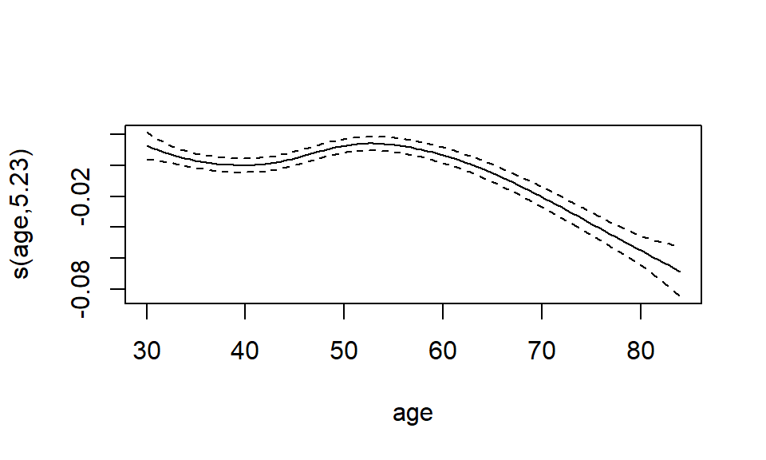

```r
# Secret trick
plot(gam_fit) # To quickly visualize the smooth terms
```

Just for fun, we could decide to fit a model with random intercepts for age (not a great idea but good show the syntax)

```r
library(lme4)
mlm_fit <- lmer(current_smoker ~ 1 + edu + sex + (1 | age_group),data=data_smoke)
summary(mlm_fit)
```

```
## Linear mixed model fit by REML ['lmerMod']
## Formula: current_smoker ~ 1 + edu + sex + (1 | age_group)
##    Data: data_smoke
##
## REML criterion at convergence: 11367.6
##
## Scaled residuals:
##     Min      1Q  Median      3Q     Max
## -0.4602 -0.3837 -0.3327 -0.1634  3.7900
##
## Random effects:
##  Groups    Name        Variance  Std.Dev.
##  age_group (Intercept) 0.0005771 0.02402
##  Residual              0.0737048 0.27149
## Number of obs: 49000, groups:  age_group, 11
##
## Fixed effects:
##                  Estimate Std. Error t value
## (Intercept)      0.086970   0.007912  10.992
## eduhigh school   0.001037   0.003745   0.277
## edusome college -0.007526   0.003791  -1.985
## edubachelor     -0.058419   0.004171 -14.007
## edugraduate     -0.070444   0.004819 -14.619
## sexmale          0.011163   0.002461   4.537
##
## Correlation of Fixed Effects:
##             (Intr) edhghs edsmcl edbchl edgrdt
## eduhighschl -0.289
## edusomcollg -0.286  0.610
## edubachelor -0.256  0.554  0.553
## edugraduate -0.220  0.480  0.478  0.435
## sexmale     -0.148  0.005  0.030  0.002 -0.014
```

### Working with Models

Back to our basic linear model, R gives use some useful functions to manipulate the model object.

```r
# Simplify model to keep things simple
lm_fit <- lm(current_smoker ~ 1 + edu + age + sex + edu:sex,data=data_smoke)
# Extract coefficients
coef(lm_fit)
```

```
##             (Intercept)          eduhigh school         edusome college
##            0.1285562939            0.0093940046            0.0003838796
##             edubachelor             edugraduate                     age
##           -0.0468754041           -0.0589692282           -0.0008044110
##                 sexmale  eduhigh school:sexmale edusome college:sexmale
##            0.0234369526           -0.0134244314           -0.0107590499
##     edubachelor:sexmale     edugraduate:sexmale
##           -0.0195474503           -0.0176802511
```

```r
# Extract variance-covariance matrix
vcov(lm_fit)
```

```
##                           (Intercept) eduhigh school edusome college
## (Intercept)              4.004924e-05  -1.647497e-05   -1.804037e-05
## eduhigh school          -1.647497e-05   2.683281e-05    1.655859e-05
## edusome college         -1.804037e-05   1.655859e-05    2.668682e-05
## edubachelor             -1.881537e-05   1.655564e-05    1.670569e-05
## edugraduate             -1.876836e-05   1.655582e-05    1.670274e-05
## age                     -4.382078e-07  -1.664890e-09    2.754397e-08
## sexmale                 -1.716126e-05   1.656193e-05    1.660172e-05
## eduhigh school:sexmale   1.592301e-05  -2.683491e-05   -1.652389e-05
## edusome college:sexmale  1.697958e-05  -1.656262e-05   -2.662014e-05
## edubachelor:sexmale      1.769061e-05  -1.655991e-05   -1.663500e-05
## edugraduate:sexmale      1.854301e-05  -1.655668e-05   -1.668857e-05
##                           edubachelor   edugraduate           age       sexmale
## (Intercept)             -1.881537e-05 -1.876836e-05 -4.382078e-07 -1.716126e-05
## eduhigh school           1.655564e-05  1.655582e-05 -1.664890e-09  1.656193e-05
## edusome college          1.670569e-05  1.670274e-05  2.754397e-08  1.660172e-05
## edubachelor              3.346768e-05  1.677548e-05  4.200475e-08  1.662143e-05
## edugraduate              1.677548e-05  4.643361e-05  4.112753e-08  1.662023e-05
## age                      4.200475e-08  4.112753e-08  8.176524e-09  1.114072e-08
## sexmale                  1.662143e-05  1.662023e-05  1.114072e-08  3.451085e-05
## eduhigh school:sexmale  -1.650273e-05 -1.650402e-05  1.196395e-08 -3.447937e-05
## edusome college:sexmale -1.660401e-05 -1.660318e-05 -7.750698e-09 -3.450623e-05
## edubachelor:sexmale     -3.335986e-05 -1.666991e-05 -2.101789e-08 -3.452431e-05
## edugraduate:sexmale     -1.675388e-05 -4.641246e-05 -3.692283e-08 -3.454598e-05
##                         eduhigh school:sexmale edusome college:sexmale
## (Intercept)                       1.592301e-05            1.697958e-05
## eduhigh school                   -2.683491e-05           -1.656262e-05
## edusome college                  -1.652389e-05           -2.662014e-05
## edubachelor                      -1.650273e-05           -1.660401e-05
## edugraduate                      -1.650402e-05           -1.660318e-05
## age                               1.196395e-08           -7.750698e-09
## sexmale                          -3.447937e-05           -3.450623e-05
## eduhigh school:sexmale            5.618132e-05            3.448433e-05
## edusome college:sexmale           3.448433e-05            5.739816e-05
## edubachelor:sexmale               3.446491e-05            3.451559e-05
## edugraduate:sexmale               3.444164e-05            3.453067e-05
##                         edubachelor:sexmale edugraduate:sexmale
## (Intercept)                    1.769061e-05        1.854301e-05
## eduhigh school                -1.655991e-05       -1.655668e-05
## edusome college               -1.663500e-05       -1.668857e-05
## edubachelor                   -3.335986e-05       -1.675388e-05
## edugraduate                   -1.666991e-05       -4.641246e-05
## age                           -2.101789e-08       -3.692283e-08
## sexmale                       -3.452431e-05       -3.454598e-05
## eduhigh school:sexmale         3.446491e-05        3.444164e-05
## edusome college:sexmale        3.451559e-05        3.453067e-05
## edubachelor:sexmale            6.916016e-05        3.459058e-05
## edugraduate:sexmale            3.459058e-05        9.264540e-05
```

```r
# Predict
predict(lm_fit)[1:5]
```

```
##          1          2          3          4          5
## 0.03499739 0.04155850 0.11417756 0.10416504 0.07021817
```

```r
# To predict on new data use predict(lm_fit,newdata=new_data)
```

```r
# Get residuals
residuals(lm_fit)[1:5]
```

```
##           1           2           3           4           5
## -0.03499739 -0.04155850  0.88582244 -0.10416504 -0.07021817
```

Want to do some fancy simulations? Easy-peasy

```r
# Get model matrix
X <- model.matrix(lm_fit,data=data_smoke)
# Get simulated coefficients from multivariate Normal
beta <- MASS::mvrnorm(1000,coef(lm_fit),vcov(lm_fit))
y <- beta %*% t(X) # Matrix algebra is great!

# Get means, medians, percentiles efficiently
library(matrixStats) # This is your friend for fast matrix manipulation
y_mean <- colMeans2(y)
y_median <- colMedians(y)
y_q <- colQuantiles(y,probs = c(0.025,0.975))

# Assemble into a data.table
y_summary <- data.table(
  y_real = data_smoke$current_smoker,
  y_mean = y_mean,
  y_median = y_median,
  y_025 = y_q[,1],
  y_975 = y_q[,2]
)

y_summary[1:5]
```

```
##    y_real     y_mean   y_median      y_025      y_975
##     <num>      <num>      <num>      <num>      <num>
## 1:      0 0.03503624 0.03509566 0.02341953 0.04573091
## 2:      0 0.04176100 0.04162383 0.03167898 0.05226078
## 3:      1 0.11432624 0.11442080 0.10754960 0.12074621
## 4:      0 0.10413513 0.10412854 0.09747949 0.11086101
## 5:      0 0.07008785 0.07004777 0.06247611 0.07754549
```

I use this basic workflow a lot to get confidence intervals for complex quantities. We could also compute the average proportion of current smokers by sex and education level.

```r
# Create new data
new_data <- expand.grid(
  current_smoker=1,
  age=30:84,
  sex=unique(data_smoke$sex),
  edu=unique(data_smoke$edu)
)
# Great function to create a data.frame from combinations of column values

# Make it a data.table
setDT(new_data)

# Get model matrix
X <- model.matrix(lm_fit,data=new_data) # Also useful to understand model structure
# Get simulated coefficients from multivariate Normal
beta <- MASS::mvrnorm(1000,coef(lm_fit),vcov(lm_fit))
y <- beta %*% t(X)

# Define groups
new_data[,group:=.GRP,by=.(sex,edu)]

# Average over age to get marginal effect
y <- sapply(unique(new_data$group), function(g) {
  rowMeans2(y[,new_data$group==g])
})
# Yes, this is a more complex version of our tapply using sapply example

# Get means, medians, percentiles efficiently
y_mean <- colMeans2(y)
y_median <- colMedians(y)
y_q <- colQuantiles(y,probs = c(0.025,0.975))

# Assemble into a data.table
y_summary <- data.table(
  y_real = data_smoke[,.(prop=mean(current_smoker)),by=.(sex,edu)],
  y_mean = y_mean,
  y_median = y_median,
  y_025 = y_q[,1],
  y_975 = y_q[,2]
)

y_summary
```

```
##     y_real.sex            y_real.edu y_real.prop     y_mean   y_median
##         <fctr>                <fctr>       <num>      <num>      <num>
##  1:     female              graduate  0.03052209 0.02341825 0.02332738
##  2:       male              graduate  0.03374233 0.02947218 0.02931510
##  3:       male           high school  0.10696095 0.09208287 0.09205211
##  4:     female           high school  0.09467538 0.10213717 0.10220075
##  5:     female          some college  0.08853884 0.08310343 0.08290825
##  6:       male          some college  0.10155025 0.09570703 0.09567378
##  7:       male less than high school  0.10997815 0.08263890 0.08279432
##  8:     female less than high school  0.08544517 0.10607120 0.10597045
##  9:       male              bachelor  0.04562000 0.03567023 0.03576382
## 10:     female              bachelor  0.04270221 0.03966312 0.03964853
##          y_025      y_975
##          <num>      <num>
##  1: 0.01304061 0.03460513
##  2: 0.01956396 0.03997512
##  3: 0.08558480 0.09876657
##  4: 0.09562326 0.10870536
##  5: 0.07738993 0.08921542
##  6: 0.08882574 0.10279652
##  7: 0.07449592 0.09083222
##  8: 0.09821770 0.11368816
##  9: 0.02725004 0.04380630
## 10: 0.03081511 0.04841903
```

We can easily visualize all of our hard work.

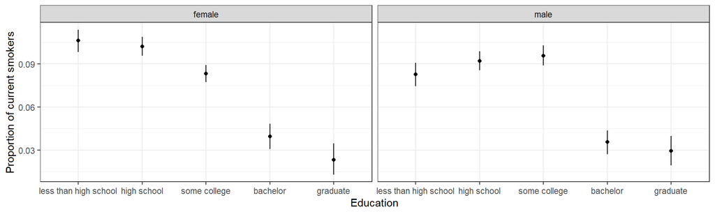

```r
# Bit of a spoiler
y_summary |>
  ggplot() +
  geom_point(mapping=aes(x=y_real.edu,y=y_mean)) +
  geom_linerange(mapping=aes(x=y_real.edu,ymin=y_025,ymax=y_975)) +
  facet_wrap(~y_real.sex) +
  labs(x='Education',y='Proportion of current smokers') +
  theme_bw()
```

Ok, this was nice!

We covered some frequently used statistical methods but there are many specialized statistical packages for other methods:

- `feols` for efficient fixed-effects estimation (economists I am looking at you!)
- `rstan` and `brms`, R interfaces to Bayesian inference with Stan
- `rjags`, R interfaces to Bayesian inference with JAGS
- `INLA`, approximate Bayesian inference
- `survival` survival models (and many utilities for survival data)
- `MASS` lots of utility functions and more statistical models (e.g. ordered logistic regression, negative binomial models)
- `nnet` (hint: you need three of these and a trenchcoat to create a multistate model)
- `censReg` censored regression models (tobit)
- `forecast` ARIMA and friends
- `DemoTools` everything demography (`DemoDecomp` for demographic decomposition methods)
- `sampleSelection` Heckman selection models

The R package environment can be confusing and there is a non trivial degree of duplication (multiple packages doing the same thing, likely with a different syntax). At the same time, R is the language of choice for the statistical community (excluding ML and economists) so the breadth of models you can fit with R is very impressive.

### Dealing with Multiple Models

Often, you’ll need to run multiple models on the same dataset. For example, we might want to run separate models for sex and race combinations. Here is one way of doing it

```r
# Create group indicator
data_smoke[,group:=.GRP,by=.(sex,race)] # .GRP is data.table lingo, there is also .N for group size
models <- vector(mode='list',length = max(data_smoke$group))

for (i in 1:length(models)) {
  this_lm_fit <- lm(current_smoker ~ 1 + edu + age,data=data_smoke[group==i])
  models[[i]] <- this_lm_fit
}
```

We could then have another loop to do something with our models. Say we want to store the predicted proportions for each individual, we could do

```r
# Create group indicator
data_smoke[,group:=.GRP,by=.(sex,race)]
# Create dictionary of groups
group_dict <- unique(data_smoke[,.(group,sex,race)]) # R is smart and dispatches unique to unique.data.table
# Set up data structure
predict_data <- vector(mode='list',length = max(data_smoke$group))

for (i in 1:length(models)) {
  this_lm_fit <- lm(current_smoker ~ 1 + edu + age,data=data_smoke[group==i])
  this_predict_data <- data.table(y_pred=predict(this_lm_fit))

  # Add group to keep track
  this_predict_data[,group:=i]

  # Add to list
  predict_data[[i]] <- this_predict_data
}

# Create single data.table
predict_data <- rbindlist(predict_data)
# Bring back group variables
predict_data <- merge(predict_data,group_dict,by='group')
```

You can make this more complicated, potentially wrapping the code inside the for loop into one or multiple functions, but the basic structure is the same.

### Combining Datasets

One more thing worth illustrating is how to combine datasets (merge). Let’s go back to our full data and suppose we want to standardize continuous BMI values so they have mean zero and a standard deviation of one. We want to do this separately by sex because the distribution might be different.

The fastest way of doing this would be:

```r
# Get rid of respondents for which BMI is missing
data_bmi <- data[!is.na(bmi_c)]

# Compute mean and standard deviation of BMI
data_bmi[,bmi_mean:=mean(bmi_c),by=.(sex)]
data_bmi[,bmi_sd:=sd(bmi_c),by=.(sex)]

# We can then create our standardized BMI scores
data_bmi[,bmi_std:=(bmi_c-bmi_mean)/bmi_sd]

# Let's check that everything is right
mean(data_bmi$bmi_std)
```

```
## [1] -3.379166e-15
```

```r
sd(data_bmi$bmi_std)
```

```
## [1] 0.9999809
```

But, if for some reason we first want to compute the sex-specific means and standard deviations, we could do so and the merge the resulting data.table onto our data:

```r
# Get rid of respondents for which BMI is missing
data_bmi <- data[!is.na(bmi_c)]

# Compute mean and standard deviation of BMI
data_bmi_summary <- data_bmi[,.(bmi_mean=mean(bmi_c),bmi_sd=sd(bmi_c)),by=.(sex)]
# Example of aggregation with by

# Merge
data_bmi <- merge(data_bmi,data_bmi_summary,by=c('sex'))

# We can then create our standardized BMI scores
data_bmi[,bmi_std:=(bmi_c-bmi_mean)/bmi_sd]

# Let's check that everything is right
mean(data_bmi$bmi_std)
```

```
## [1] -3.379166e-15
```

```r
sd(data_bmi$bmi_std)
```

```
## [1] 0.9999809
```

The result is the same. The operation we just performed is also known as joining. There are four types which `data.table` conveniently handles with just one function:

- Inner join: keeps only entries found in both databases. This is the default option.
- Left join: keeps only entries found in left database. Specify option `all.x=T`.
- Right join: keeps only entries found in left database. Specify option `all.y=T`.
- Outer join: keeps any entry found in one of the two databases. Specify option `all=T`.

Also, the two data.table might have different names for the same variables. It is possible to specify different merging variables in the first (x) and second (y) table with options `by.x` and `by.y`. However, I think having consistent names across tables is advisable.